# 第10回 外部データの読込とパッケージのインストール

プログラミング演習Ⅰ

佐藤 秀保

sato0035@toyo.jp

## 先週までの内容

- データフレームを学習
- 複数の「長さが同じアトミックベクトル」をそれぞれ列としてまとめた表形式データ

```r
#3つの「長さ5のアトミックベクトル」
ID <- c(1, 2, 3, 4, 5)
gender <- c("女", "女", "男", "男", "男")
calorie <- c(2100, 2200, 2300, 2400, 2500)

#data.frame関数でデータフレーム作成
df1 <- data.frame(ID, gender, calorie)
```

- 列**内**では同一の型，列**間**では異なる型
- データフレームからのデータ抽出例

```r
df1[1, 2] #1さんの性別
df1[1, -2] #1さんの性別以外
df1[c(T, F, F, F, F), c(F, T, F)] #1さんの性別
df1[1,] #1さんについてすべての列（番号，性別，摂取カロリー）

df1[calorie] #摂取カロリーの列をデータフレームとして抽出
df1[[calorie]] #摂取カロリーの列をアトミックベクトルとして抽出

#アクセッサー$を使う
df1$calorie #摂取カロリーの列をアトミックベクトルとして抽出
```

## 準備

1. [Posit Cloud](https://posit.cloud/)へ（日本語訳しないことを推奨）
2. 作成済みのプロジェクトをクリック
3. 先週使用のスクリプトをすべて閉じる
4. 新しくスクリプトを作成
5. 作成したスクリプトを保存：名前は「lec10」
6. ほうきボタンでオブジェクトを削除

授業中のコードはすべてスクリプトに書き実行すること

## 外部データの読込

- いままでは，データを直に手打ち

```r
#性別のデータ
gender <- c("女", "女", "男", "男", "男")
```

- 通常，既にあるエクセルデータをRに読み込ませ，そのデータを加工・分析
- 今日は，ACEにアップロードのエクセルファイル「syokudo_data1」を読み込む
  - 朝霞キャンパス食堂の日別売上データ（2026年6月1～16日）

### 外部データの読込方法（Posit Cloud）

1. **ローカルにエクセルファイルを保存**
   - 「syokudo_data1」をACEから適当な場所に保存
2. **Posit Cloudにエクセルファイルをアップロード**
   - Filesペイン「Upload」
   - 「ファイルを選択」
   - 1の保存場所で「syokudo_data1」を選択し「開く」
   - 「OK」
   - Filesペインで「syokudo_data1.xlsx」の存在を確認
3. **アップロードしたエクセルファイルを読込**

```r
#エクセルファイル読込のためのパッケージ「readxl」をインストール
install.packages("readxl")
#パッケージ「readxl」を読み込む
library(readxl)
#「read_xl」関数でエクセルデータを読み込んで保存
df <- read_excel("syokudo_data1.xlsx")
```

Environmentペインのdfをクリックして中身を確認

### 【参考】手順3以降の別の方法（現在，エラー）

3. **アップロードしたエクセルファイルを読込**
   - Environmentペインの「Import Dataset」
   - 「From Excel」
4. **読込用のパッケージをインストール**
   - Install Required Packagesの表示で「Yes」
   - しばしお待ちください（手順４は１度実行すれば今後表示されない）
5. **読込ファイルの選択と読込**
   - 右上の「Browse」から「syokudo_data1」を選択し「Open」
     - どのような形式で読み込まれるかプレビューが表示
     - 右下には手順５のコードの記載あり
   - 右下の「Import」
   - Environmentペインで「syokudo_data1」の存在を確認

### 【参考】外部データの読込方法（デスクトップ版RStudio）

- Posit Cloudの手順２番目を省略し，他同様
  - インターネットに接続せず完結するため，クラウドにファイルをアップロードする必要なし

## パッケージの意義

- Rでデフォルトで使用できる関数などは限定的
  - 例：ルート（sqrt関数），絶対値（abs関数）…
- 外部から必要な関数などを適宜インストールし使えるようにすることが一般的
  - 例：エクセルファイルを読み込む（read_excel関数）…
- 外部の関数などがまとまったものはパッケージpackage

## パッケージのインストールとライブラリの読込

- install.packages関数でパッケージをインストールし，
- その後，library関数で読み込む
  - 例：データ加工系の**tidyverse**パッケージを導入

```r
install.packages("tidyverse") #ダブルクォーテーション必要
library(tidyverse) #ダブルクォーテーション不要
```

- 原則，install.packagesは一度実行すればOK，libraryはR起動の度に要実行
- libraryを実行せずそのパッケージにある関数を使おうとするとエラー
  - Error in 〇〇: could not find function “△△”

## tidyverse

- データに関する操作を統一的・直感的に行い，tidyな（整然とした）データを作成するツール群
- Hadley Wickham氏（R神）などが中心となり開発

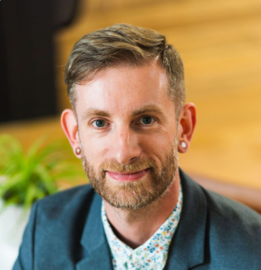

### tidyverseに含まれるパッケージ

- tidyverseには，複数の小さなパッケージが含まれる

[figure not shown]

データ加工dplyr

[figure not shown]

文字操作stringr

[figure not shown]

データ可視化ggplot2

[figure not shown]

繰り返し操作purrr

などなど…

- 本授業では，dplyrやggplot2を扱う

## dplyr でぃぷらいあーる

- データフレーム操作の基本パッケージ
  - 行の抽出：filter関数
  - 列の抽出：select関数
  - 列の追加：mutate関数
  - 列名の変更：rename関数
  - 記述統計量：summarise関数
  - データフレームの結合：〇〇_join関数

などなど…

### select関数

- 列の抽出

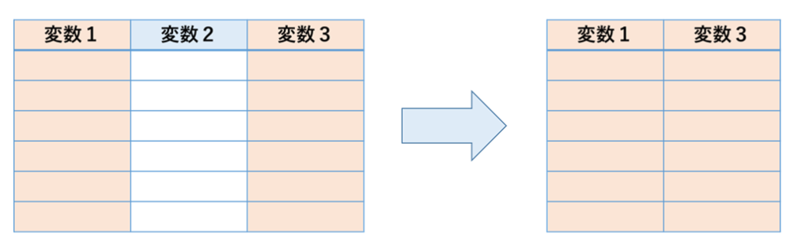

- 文法：select(データフレーム名, 列名１, 列名2, …)
  - syokudo_data1から「日付」，「総売上」の列を抽出
  - df1という名前に保存

```r
df1 <- select(df, 日付, 総売上)
```

## 演習

syokudo_data1から「日付」，「総売上」，「販売点数」，「客数」，の列のみを抽出し，df_ensyuuという名前にデータフレームとして保存せよ．

## filter関数

- 行の抽出

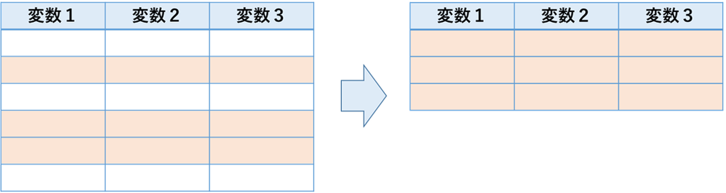

**文法：filter(データフレーム名, 条件式１, 条件式2, …)**

- syokudo_data1から「総売上」> 0に該当する行を抽出
- df2という名前に保存

```r
df2 <- filter(df, 総売上 > 0)
```

- syokudo_data1から「総売上」 >0 かつ「客数」 >= 400に該当する行を抽出
- df3という名前に保存

```r
#コンマの後などで改行すると見やすい場合あり
df3 <- filter(df,
              総売上 > 0,
              客数 >= 400)
```

## 課題

- ACEの小テスト：「第10回」
- ACEのレポート：「第10回」
  - ローカルに保存したlec10.Rを提出